# DIHARD_comparison

EB

1/5/2020

Looking at the DIHARD2 data that Neville sent along to Alex to add to eval. (I wasn’t sure if this data was okay for public facing purposes so i just put it in a dropbox folder, but can move to github, just lmk. I.e. this won’t knit for you if you don’t also put the data from neville in that path)

Just looking at track 1 and 2 since it was single channel

- Track 1 – single channel audio using reference SAD
- Track 2 – single channel audio using system SAD

```r
track1 <- read_tsv("~/Dropbox/dihard_lena_eval/dihard2_scoring/data/track1/scores_by_domain.tsv") %>%
  filter(Domain=="CHILD" & IsFinal==T) %>%
  mutate(track = "track1")
track2 <-read_tsv("~/Dropbox/dihard_lena_eval/dihard2_scoring/data/track2/scores_by_domain.tsv") %>%
  filter(Domain=="CHILD" & IsFinal==T) %>%
  mutate(track = "track2")
track1_2 <- bind_rows(track1, track2)
#View(track1)
#View(track2)
```

# Initial look

- any other filtering i should be doing?

```r
summary(track1_2)
```

```
##   SubmissionID       Datetime                        Date
##  Min.   : 520.0   Min.   :2019-04-02 14:26:09   Min.   :2019-04-02
##  1st Qu.: 704.8   1st Qu.:2019-04-15 03:50:28   1st Qu.:2019-04-15
##  Median : 889.5   Median :2019-05-22 20:42:35   Median :2019-05-22
##  Mean   : 908.7   Mean   :2019-05-22 11:05:58   Mean   :2019-05-21
##  3rd Qu.:1091.2   3rd Qu.:2019-06-26 09:56:58   3rd Qu.:2019-06-26
##  Max.   :1301.0   Max.   :2019-07-02 11:59:36   Max.   :2019-07-02
##      User               Team              System          RTTMDirname
##  Length:252         Length:252         Length:252         Length:252
##  Class :character   Class :character   Class :character   Class :character
##  Mode  :character   Mode  :character   Mode  :character   Mode  :character
##
##
##
##  IsFinal        IsDisplayed        Domain               DER
##  Mode:logical   Mode :logical   Length:252         Min.   : 34.64
##  TRUE:252       FALSE:64        Class :character   1st Qu.: 38.77
##                 TRUE :188       Mode  :character   Median : 41.49
##                                                    Mean   : 52.10
##                                                    3rd Qu.: 65.44
##                                                    Max.   :121.06
##       JER          B3Precision        B3Recall           B3F1
##  Min.   : 61.63   Min.   :0.3800   Min.   :0.4100   Min.   :0.4300
##  1st Qu.: 70.92   1st Qu.:0.5175   1st Qu.:0.6700   1st Qu.:0.5700
##  Median : 74.08   Median :0.7000   Median :0.8200   Median :0.7600
##  Mean   : 75.16   Mean   :0.6350   Mean   :0.7794   Mean   :0.6968
##  3rd Qu.: 79.77   3rd Qu.:0.7200   3rd Qu.:0.8800   3rd Qu.:0.7800
##  Max.   :100.00   Max.   :0.8200   Max.   :1.0000   Max.   :0.8100
##   GKT_ref_sys      GKT_sys_ref       H_ref_sys       H_sys_ref
##  Min.   :0.4100   Min.   :0.3700   Min.   :0.500   Min.   :0.0000
##  1st Qu.:0.6600   1st Qu.:0.5100   1st Qu.:0.860   1st Qu.:0.2875
##  Median :0.8150   Median :0.6900   Median :0.915   Median :0.4800
##  Mean   :0.7751   Mean   :0.6282   Mean   :1.097   Mean   :0.5696
##  3rd Qu.:0.8800   3rd Qu.:0.7100   3rd Qu.:1.442   3rd Qu.:0.8300
##  Max.   :1.0000   Max.   :0.8100   Max.   :1.830   Max.   :1.7700
##        MI             NMI            track
##  Min.   :4.520   Min.   :0.7500   Length:252
##  1st Qu.:4.910   1st Qu.:0.8100   Class :character
##  Median :5.440   Median :0.8900   Mode  :character
##  Mean   :5.259   Mean   :0.8645
##  3rd Qu.:5.490   3rd Qu.:0.9000
##  Max.   :5.850   Max.   :0.9200
```

```r
glimpse(track1_2)
```

```
## Observations: 252
## Variables: 22
## $ SubmissionID <dbl> 520, 521, 589, 590, 591, 592, 593, 594, 595, 598, 606, 6…
## $ Datetime     <dttm> 2019-04-02 14:26:09, 2019-04-02 14:36:52, 2019-04-06 12…
## $ Date         <date> 2019-04-02, 2019-04-02, 2019-04-06, 2019-04-06, 2019-04…
## $ User         <chr> "dihard2019", "dihard2019", "prachis", "prachis", "prach…
## $ Team         <chr> "DIHARD", "DIHARD", "LEAP", "LEAP", "LEAP", "LEAP", "LEA…
## $ System       <chr> "test bad name", "None", "baseline_updated", "baseline",…
## $ RTTMDirname  <chr> "520_dihard_test_bad_name", "521_dihard_none", "589_leap…
## $ IsFinal      <lgl> TRUE, TRUE, TRUE, TRUE, TRUE, TRUE, TRUE, TRUE, TRUE, TR…
## $ IsDisplayed  <lgl> FALSE, FALSE, TRUE, TRUE, TRUE, TRUE, TRUE, TRUE, TRUE, …
## $ Domain       <chr> "CHILD", "CHILD", "CHILD", "CHILD", "CHILD", "CHILD", "C…
## $ DER          <dbl> 100.70, 100.70, 36.39, 36.14, 37.51, 40.91, 41.26, 38.99…
## $ JER          <dbl> 98.53, 98.53, 71.64, 71.82, 71.85, 72.86, 69.54, 75.32, …
## $ B3Precision  <dbl> 0.38, 0.38, 0.71, 0.71, 0.71, 0.71, 0.73, 0.69, 0.69, 0.…
## $ B3Recall     <dbl> 0.97, 0.97, 0.89, 0.90, 0.88, 0.83, 0.79, 0.92, 0.90, 0.…
## $ B3F1         <dbl> 0.55, 0.55, 0.79, 0.80, 0.78, 0.77, 0.76, 0.79, 0.78, 0.…
## $ GKT_ref_sys  <dbl> 0.97, 0.97, 0.89, 0.90, 0.87, 0.83, 0.79, 0.92, 0.90, 0.…
## $ GKT_sys_ref  <dbl> 0.37, 0.37, 0.71, 0.71, 0.71, 0.71, 0.72, 0.68, 0.69, 0.…
## $ H_ref_sys    <dbl> 1.81, 1.81, 0.86, 0.86, 0.87, 0.87, 0.82, 0.97, 0.95, 0.…
## $ H_sys_ref    <dbl> 0.11, 0.11, 0.27, 0.23, 0.30, 0.42, 0.54, 0.21, 0.25, 0.…
## $ MI           <dbl> 4.54, 4.54, 5.49, 5.49, 5.48, 5.49, 5.54, 5.39, 5.40, 5.…
## $ NMI          <dbl> 0.84, 0.84, 0.91, 0.91, 0.90, 0.90, 0.89, 0.90, 0.90, 0.…
## $ track        <chr> "track1", "track1", "track1", "track1", "track1", "track…
```

```r
skim(track1_2)
```

Data summary

| Name | track1_2 |
| --- | --- |
| Number of rows | 252 |
| Number of columns | 22 |
| _______________________ |  |
| Column type frequency: |  |
| character | 6 |
| Date | 1 |
| logical | 2 |
| numeric | 12 |
| POSIXct | 1 |
| ________________________ |  |
| Group variables | None |

**Variable type: character**

| skim_variable | n_missing | complete_rate | min | max | empty | n_unique | whitespace |
| --- | --- | --- | --- | --- | --- | --- | --- |
| User | 0 | 1 | 3 | 14 | 0 | 22 | 0 |
| Team | 0 | 1 | 3 | 14 | 0 | 21 | 0 |
| System | 0 | 1 | 4 | 20 | 0 | 229 | 0 |
| RTTMDirname | 0 | 1 | 13 | 36 | 0 | 252 | 0 |
| Domain | 0 | 1 | 5 | 5 | 0 | 1 | 0 |
| track | 0 | 1 | 6 | 6 | 0 | 2 | 0 |

**Variable type: Date**

| skim_variable | n_missing | complete_rate | min | max | median | n_unique |
| --- | --- | --- | --- | --- | --- | --- |
| Date | 0 | 1 | 2019-04-02 | 2019-07-02 | 2019-05-22 | 55 |

**Variable type: logical**

| skim_variable | n_missing | complete_rate | mean | count |
| --- | --- | --- | --- | --- |
| IsFinal | 0 | 1 | 1.00 | TRU: 252 |
| IsDisplayed | 0 | 1 | 0.75 | TRU: 188, FAL: 64 |

**Variable type: numeric**

| skim_variable | n_missing | complete_rate | mean | sd | p0 | p25 | p50 | p75 | p100 | hist |
| --- | --- | --- | --- | --- | --- | --- | --- | --- | --- | --- |
| SubmissionID | 0 | 1 | 908.69 | 218.10 | 520.00 | 704.75 | 889.50 | 1091.25 | 1301.00 | ▇▅▇▅▆ |
| DER | 0 | 1 | 52.10 | 18.50 | 34.64 | 38.77 | 41.49 | 65.44 | 121.06 | ▇▂▂▁▁ |
| JER | 0 | 1 | 75.16 | 6.10 | 61.63 | 70.92 | 74.07 | 79.77 | 100.00 | ▃▇▆▁▁ |
| B3Precision | 0 | 1 | 0.63 | 0.11 | 0.38 | 0.52 | 0.70 | 0.72 | 0.82 | ▁▃▁▇▁ |
| B3Recall | 0 | 1 | 0.78 | 0.13 | 0.41 | 0.67 | 0.82 | 0.88 | 1.00 | ▁▃▅▇▅ |
| B3F1 | 0 | 1 | 0.70 | 0.11 | 0.43 | 0.57 | 0.76 | 0.78 | 0.81 | ▁▃▁▁▇ |
| GKT_ref_sys | 0 | 1 | 0.78 | 0.13 | 0.41 | 0.66 | 0.82 | 0.88 | 1.00 | ▁▅▅▇▅ |
| GKT_sys_ref | 0 | 1 | 0.63 | 0.11 | 0.37 | 0.51 | 0.69 | 0.71 | 0.81 | ▁▅▁▇▁ |
| H_ref_sys | 0 | 1 | 1.10 | 0.31 | 0.50 | 0.86 | 0.92 | 1.44 | 1.83 | ▁▇▁▃▁ |
| H_sys_ref | 0 | 1 | 0.57 | 0.35 | 0.00 | 0.29 | 0.48 | 0.83 | 1.77 | ▇▇▆▂▁ |
| MI | 0 | 1 | 5.26 | 0.31 | 4.52 | 4.91 | 5.44 | 5.49 | 5.85 | ▁▃▁▇▁ |
| NMI | 0 | 1 | 0.86 | 0.05 | 0.75 | 0.81 | 0.89 | 0.90 | 0.92 | ▁▃▂▂▇ |

**Variable type: POSIXct**

| skim_variable | n_missing | complete_rate | min | max | median | n_unique |
| --- | --- | --- | --- | --- | --- | --- |
| Datetime | 0 | 1 | 2019-04-02 14:26:09 | 2019-07-02 11:59:36 | 2019-05-22 20:42:35 | 252 |

## Boxplot

but the value’s here don’t look exactly the same as his CHILD boxplot in this folder: is2019_dihard2_figures for DIHARD2 track 1 or track 2 DER

- maybe he used different filtering on the data?
- maybe i shouldn’t allow multiples per User/team?

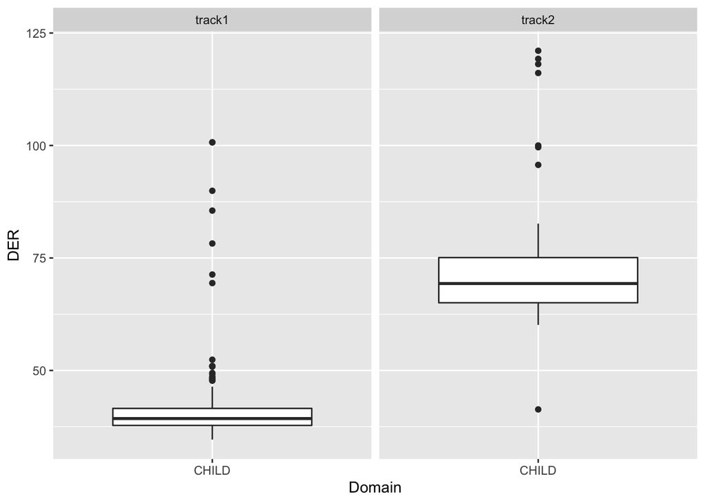

```r
ggplot(track1_2, aes(Domain, DER))+geom_boxplot()+
  facet_wrap(~track)
```

## Summary descriptives

(mean, median, min, max DER)

```r
track1_2 %>%
  summarise(mean(DER),
            median(DER),
            min(DER),
            max(DER)
            )
```

```
## # A tibble: 1 x 4
##   `mean(DER)` `median(DER)` `min(DER)` `max(DER)`
##         <dbl>         <dbl>      <dbl>      <dbl>
## 1        52.1          41.5       34.6       121.
```

```r
track1_2 %>%
  group_by(track) %>%
  summarise(mean(DER),
            median(DER),
            min(DER),
            max(DER)
            )
```

```
## # A tibble: 2 x 5
##   track  `mean(DER)` `median(DER)` `min(DER)` `max(DER)`
##   <chr>        <dbl>         <dbl>      <dbl>      <dbl>
## 1 track1        41.9          39.3       34.6       101.
## 2 track2        72.9          69.3       41.3       121.
```